# Final Project Report

## Team Members

Phu Gia Pham

Tejas Mirashi

## 1. Introduction

### I. The Purposes

#### a. Motivation of the Project

Recently, due to the COVID-19 pandemic, lots of companies have been struggling to maintain their businesses, and some of them even had to file for bankruptcy. One of the businesses that have been affected the most is the Airline industry as it is based on the hospitality industry and most people in the world are now afraid of travelling with the COVID-19 and government restriction. However, once the effect of pandemic subsides, air travel will again pick up pace. Therefore, all the Airline companies need to focus on the customer’s experience and satisfaction to create their competitive advantage.

#### b. The Purpose

In this project, we focus on analyzing what factors affect the customer satisfaction when experiencing their flight in order to help the Airlines companies have a deep look into their services.

### II. Why is this question important?

It is important for Airlines companies, especially their sales and operating managers, to understand their customers behavior in order to not only emphasize their strengths but also find out solutions to improve their weakness in customer services. From here, the quality of services provided by Airline companies will be controlled and adjusted in accordance with customers’ needs and promote the company revenue by bringing in new customers and returning customers.

### III. The brief summary of findings

The findings are quite surprising. The passengers tagged as loyal are dissatisfied with the flight experience. The airline needs to revisit the criteria which they use to tag the passenger as loyal or disloyal. The airline can design a separate survey for loyal customers and try to dig in to the reason as to why loyal passengers are dissatisfied. Once reason can be that loyal passengers expect more and hence stay dissatisfied. There can be many such reasons which the airline can investigate in to.

## 2. Main

### I. Data Processing/Cleaning

At the beginning, we were about to use both datasets from Kaggle, but we decided to analyze the first dataset which includes more than 25,800 observations. Even though using all dataset will provide enough data to improve accuracy, but at the same time, this will affect our conclusions by outliers such as departure delay in minutes and arrival delay in minutes.

```python
import pandas as pd
import numpy as np
import seaborn as sns
import matplotlib.pyplot as plt
import statsmodels.formula.api as smf
import statsmodels.api as sm
```

```python
raw = r'test.csv'
df_1=pd.read_csv(raw)
```

```python
#Number of Observations before revoming NaN value
df_1.shape
```

```
(25976, 25)
```

```python
#Revoming NaN values in column Arrival Delay in Minutes
df_1.dropna(subset = ["Arrival Delay in Minutes"], inplace=True)
```

```python
df_1.shape
```

```
(25893, 25)
```

### II. Description of the Dataset including the List of Fields

#### a. Source of Dataset

The data is taken from Kaggle dataset which is a web service platform for data.

https://www.kaggle.com/teejmahal20/airline-passenger-satisfaction

#### b. Description of the Dataset

[figure not shown]

#### c. Data Type of Fields

```python
#Type of the Dataset
type(df_1)
```

```
pandas.core.frame.DataFrame
```

```python
# Series with the data type of each column
df_1.dtypes
```

```
Unnamed: 0                             int64
id                                     int64
Gender                                object
Customer Type                         object
Age                                    int64
Type of Travel                        object
Class                                 object
Flight Distance                        int64
Inflight wifi service                  int64
Departure/Arrival time convenient      int64
Ease of Online booking                 int64
Gate location                          int64
Food and drink                         int64
Online boarding                        int64
Seat comfort                           int64
Inflight entertainment                 int64
On-board service                       int64
Leg room service                       int64
Baggage handling                       int64
Checkin service                        int64
Inflight service                       int64
Cleanliness                            int64
Departure Delay in Minutes             int64
Arrival Delay in Minutes             float64
satisfaction                          object
dtype: object
```

```python
#Columns labels of the Dataset
df_1.columns
```

```
Index(['Unnamed: 0', 'id', 'Gender', 'Customer Type', 'Age', 'Type of Travel',
       'Class', 'Flight Distance', 'Inflight wifi service',
       'Departure/Arrival time convenient', 'Ease of Online booking',
       'Gate location', 'Food and drink', 'Online boarding', 'Seat comfort',
       'Inflight entertainment', 'On-board service', 'Leg room service',
       'Baggage handling', 'Checkin service', 'Inflight service',
       'Cleanliness', 'Departure Delay in Minutes', 'Arrival Delay in Minutes',
       'satisfaction'],
      dtype='object')
```

```python
#An array of values of the Dataset
df_1.values
```

```
array([[0, 19556, 'Female', ..., 50, 44.0, 'satisfied'],
       [1, 90035, 'Female', ..., 0, 0.0, 'satisfied'],
       [2, 12360, 'Male', ..., 0, 0.0, 'neutral or dissatisfied'],
       ...,
       [25973, 37675, 'Female', ..., 0, 0.0, 'neutral or dissatisfied'],
       [25974, 90086, 'Male', ..., 0, 0.0, 'satisfied'],
       [25975, 34799, 'Female', ..., 0, 0.0, 'neutral or dissatisfied']],
      dtype=object)
```

### III. Basic descriptive features of the data

#### a. Number of Observations

83 observations were removed from the dataset as they had missing values in column Arrival Delay in Minutes. The reason why we decided to remove these observations becaues the data is already big enough for us to draw conclusion from the dataset.

```python
# The dimensiionality of the Dataset
df_1.shape
```

```
(25893, 25)
```

25893 observations will be observed in this project

#### b. Number of Observations by Variable/Field

```python
#Summary of the Dataset
df_1.info()
```

```
<class 'pandas.core.frame.DataFrame'>
Int64Index: 25893 entries, 0 to 25975
Data columns (total 25 columns):
 #   Column                             Non-Null Count  Dtype
---  ------                             --------------  -----
 0   Unnamed: 0                         25893 non-null  int64
 1   id                                 25893 non-null  int64
 2   Gender                             25893 non-null  object
 3   Customer Type                      25893 non-null  object
 4   Age                                25893 non-null  int64
 5   Type of Travel                     25893 non-null  object
 6   Class                              25893 non-null  object
 7   Flight Distance                    25893 non-null  int64
 8   Inflight wifi service              25893 non-null  int64
 9   Departure/Arrival time convenient  25893 non-null  int64
```

[output cut: 17 more lines]

#### c. Number of Missing Values by Variable/Field

```python
#The number of missing values
df_1.isnull().sum(axis=0)
```

```
Unnamed: 0                            0
id                                    0
Gender                                0
Customer Type                         0
Age                                   0
Type of Travel                        0
Class                                 0
Flight Distance                       0
Inflight wifi service                 0
Departure/Arrival time convenient     0
Ease of Online booking                0
Gate location                         0
Food and drink                        0
Online boarding                       0
Seat comfort                          0
Inflight entertainment                0
On-board service                      0
Leg room service                      0
Baggage handling                      0
Checkin service                       0
Inflight service                      0
Cleanliness                           0
Departure Delay in Minutes            0
Arrival Delay in Minutes             83
satisfaction                          0
dtype: int64
```

According to the code above, there are 83 values missing in the Arrival Delay in Minutes. The rest is fine and has no missing data.

#### d. Describe the Data

```python
round(df_1.describe(),2)
```

|  | Unnamed: 0 | id | Age | Flight Distance | Inflight wifi service | Departure/Arrival time convenient | Ease of Online booking | Gate location | Food and drink | Online boarding | Seat comfort | Inflight entertainment | On-board service | Leg room service | Baggage handling | Checkin service | Inflight service | Cleanliness | Departure Delay in Minutes | Arrival Delay in Minutes |
| --- | --- | --- | --- | --- | --- | --- | --- | --- | --- | --- | --- | --- | --- | --- | --- | --- | --- | --- | --- | --- |
| count | 25893.00 | 25893.00 | 25893.00 | 25893.00 | 25893.00 | 25893.00 | 25893.00 | 25893.00 | 25893.00 | 25893.00 | 25893.00 | 25893.00 | 25893.00 | 25893.00 | 25893.00 | 25893.00 | 25893.00 | 25893.00 | 25893.00 | 25893.00 |
| mean | 12987.84 | 65021.97 | 39.62 | 1193.75 | 2.72 | 3.05 | 2.76 | 2.98 | 3.21 | 3.26 | 3.45 | 3.36 | 3.39 | 3.35 | 3.63 | 3.31 | 3.65 | 3.29 | 14.23 | 14.74 |
| std | 7499.18 | 37606.10 | 15.13 | 998.63 | 1.33 | 1.53 | 1.41 | 1.28 | 1.33 | 1.36 | 1.32 | 1.34 | 1.28 | 1.32 | 1.18 | 1.27 | 1.18 | 1.32 | 37.19 | 37.52 |
| min | 0.00 | 17.00 | 7.00 | 31.00 | 0.00 | 0.00 | 0.00 | 1.00 | 0.00 | 0.00 | 1.00 | 0.00 | 0.00 | 0.00 | 1.00 | 1.00 | 0.00 | 0.00 | 0.00 | 0.00 |
| 25% | 6496.00 | 32209.00 | 27.00 | 414.00 | 2.00 | 2.00 | 2.00 | 2.00 | 2.00 | 2.00 | 2.00 | 2.00 | 2.00 | 2.00 | 3.00 | 3.00 | 3.00 | 2.00 | 0.00 | 0.00 |
| 50% | 12984.00 | 65344.00 | 40.00 | 849.00 | 3.00 | 3.00 | 3.00 | 3.00 | 3.00 | 4.00 | 4.00 | 4.00 | 4.00 | 4.00 | 4.00 | 3.00 | 4.00 | 3.00 | 0.00 | 0.00 |
| 75% | 19482.00 | 97623.00 | 51.00 | 1744.00 | 4.00 | 4.00 | 4.00 | 4.00 | 4.00 | 4.00 | 5.00 | 4.00 | 4.00 | 4.00 | 5.00 | 4.00 | 5.00 | 4.00 | 12.00 | 13.00 |
| max | 25975.00 | 129877.00 | 85.00 | 4983.00 | 5.00 | 5.00 | 5.00 | 5.00 | 5.00 | 5.00 | 5.00 | 5.00 | 5.00 | 5.00 | 5.00 | 5.00 | 5.00 | 5.00 | 1128.00 | 1115.00 |

### iv. Analysis and Explanations

#### How many percentage of customers are satisfied or dissatisfied about the overall airline experience?

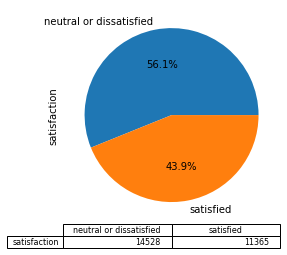

```python
df_1['satisfaction'].value_counts().plot(kind='pie',table=True, autopct='%1.1f%%')
```

As we can see, there are more dissatisfied / neutral passengers than satisfied ones. The airline needs to dig deeper in to the reasons and implement measures to improve this scenario.

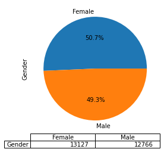

```python
df_1['Gender'].value_counts().plot(kind='pie',table=True, autopct='%1.1f%%')
```

Continuing the earlier scenario, the distribution based on gender is almost equal. As a remedy, the airline may analyze the genderwise preferences to make the flight experience a better one.

#### Distribution of passenger types

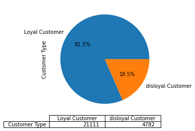

```python
df_1['Customer Type'].value_counts().plot(kind='pie',table=True, autopct='%1.1f%%')
```

As a percentage, the distribution is highly tilted towards the passengers tagged as loyal. However, we need to analyze if the criteria of tagging if the distribution as per the above pie chart, is similar to the distribution between satisfied and dissatisfied / neutral.

#### 1. Is there a regression between the delay in departure and arrival times?

```python
df_delay=df_1.groupby(['Departure Delay in Minutes']).mean()
df_delay.head()
```

| Departure Delay in Minutes | Unnamed: 0 | id | Age | Flight Distance | Inflight wifi service | Departure/Arrival time convenient | Ease of Online booking | Gate location | Food and drink | Online boarding | Seat comfort | Inflight entertainment | On-board service | Leg room service | Baggage handling | Checkin service | Inflight service | Cleanliness | Arrival Delay in Minutes |
| --- | --- | --- | --- | --- | --- | --- | --- | --- | --- | --- | --- | --- | --- | --- | --- | --- | --- | --- | --- |
| 0 | 13021.841646 | 62479.982943 | 39.644880 | 1183.155352 | 2.748243 | 3.054991 | 2.763935 | 2.965068 | 3.239203 | 3.291465 | 3.466603 | 3.391895 | 3.415842 | 3.354779 | 3.647336 | 3.332128 | 3.680085 | 3.311455 | 1.891110 |
| 1 | 13032.566940 | 74755.225410 | 38.926230 | 1205.103825 | 2.693989 | 2.995902 | 2.762295 | 2.964481 | 3.191257 | 3.178962 | 3.428962 | 3.256831 | 3.250000 | 3.367486 | 3.605191 | 3.247268 | 3.606557 | 3.224044 | 3.168033 |
| 2 | 12503.811744 | 73226.663212 | 38.974093 | 1288.132988 | 2.747841 | 3.012090 | 2.746114 | 2.899827 | 3.186528 | 3.305699 | 3.502591 | 3.340242 | 3.411054 | 3.331606 | 3.656304 | 3.341969 | 3.659758 | 3.241796 | 3.735751 |
| 3 | 13046.286260 | 69788.326336 | 39.328244 | 1169.318702 | 2.664122 | 2.975191 | 2.671756 | 3.030534 | 3.154580 | 3.227099 | 3.465649 | 3.320611 | 3.337786 | 3.349237 | 3.616412 | 3.318702 | 3.656489 | 3.217557 | 4.471374 |
| 4 | 13096.794702 | 66793.441501 | 39.456954 | 1262.342163 | 2.704194 | 3.050773 | 2.626932 | 2.940397 | 3.121413 | 3.282561 | 3.415011 | 3.366446 | 3.481236 | 3.326711 | 3.640177 | 3.357616 | 3.662252 | 3.256071 | 5.505519 |

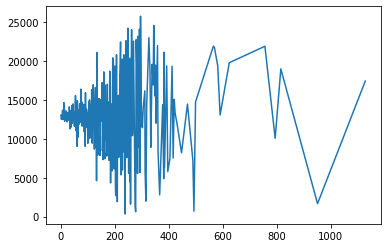

```python
plt.plot(df_delay['Unnamed: 0'])
plt.show()
```

```python
df_arrival=df_1.groupby(['Arrival Delay in Minutes']).mean()
df_arrival.head()
```

| Arrival Delay in Minutes | Unnamed: 0 | id | Age | Flight Distance | Inflight wifi service | Departure/Arrival time convenient | Ease of Online booking | Gate location | Food and drink | Online boarding | Seat comfort | Inflight entertainment | On-board service | Leg room service | Baggage handling | Checkin service | Inflight service | Cleanliness | Departure Delay in Minutes |
| --- | --- | --- | --- | --- | --- | --- | --- | --- | --- | --- | --- | --- | --- | --- | --- | --- | --- | --- | --- |
| 0.0 | 13001.656708 | 64627.640263 | 39.653282 | 1200.067905 | 2.761066 | 3.048170 | 2.768741 | 2.963410 | 3.238386 | 3.306564 | 3.480540 | 3.401192 | 3.429971 | 3.372482 | 3.665890 | 3.344662 | 3.699671 | 3.318144 | 1.064753 |
| 1.0 | 12398.304104 | 67888.552239 | 39.927239 | 1301.912313 | 2.742537 | 3.057836 | 2.779851 | 2.916045 | 3.268657 | 3.401119 | 3.572761 | 3.498134 | 3.559701 | 3.414179 | 3.781716 | 3.367537 | 3.757463 | 3.402985 | 3.501866 |
| 2.0 | 13379.617591 | 65531.684512 | 39.476099 | 1169.504780 | 2.711281 | 2.971319 | 2.722753 | 2.952199 | 3.183556 | 3.166348 | 3.439771 | 3.330784 | 3.414914 | 3.407266 | 3.565966 | 3.250478 | 3.592734 | 3.239006 | 3.537285 |
| 3.0 | 12917.681633 | 69212.932653 | 39.906122 | 1192.373469 | 2.706122 | 3.112245 | 2.722449 | 3.008163 | 3.269388 | 3.281633 | 3.485714 | 3.414286 | 3.502041 | 3.353061 | 3.693878 | 3.324490 | 3.748980 | 3.300000 | 4.246939 |
| 4.0 | 12974.399142 | 67539.060086 | 39.875536 | 1186.879828 | 2.776824 | 3.152361 | 2.819742 | 3.004292 | 3.261803 | 3.268240 | 3.504292 | 3.349785 | 3.334764 | 3.373391 | 3.553648 | 3.394850 | 3.650215 | 3.302575 | 5.182403 |

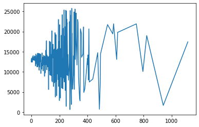

```python
plt.plot(df_arrival['Unnamed: 0'])
plt.show()
```

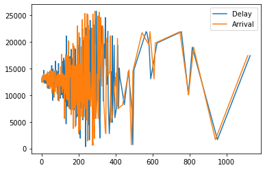

```python
plt.plot(df_delay['Unnamed: 0'], label ="Delay")
plt.plot(df_arrival['Unnamed: 0'], label ="Arrival")
plt.legend()
plt.show()
```

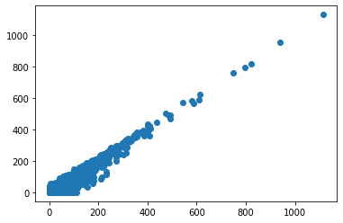

```python
plt.scatter(df_1['Arrival Delay in Minutes'],df_1['Departure Delay in Minutes'])
```

On analyzing the arrival and departure delay departure times, we understand that there is a very close relation between both the variables. The outcome is quite logical as once there is a delay in arrival, there ought to be a delay in departure.

Predictive suggestion – The airline can predict the estimated delay in departure once they know the delay in arrival.

Prescriptive suggestion – Once the delay in departure is predicted, the airline can arrive at a cut-off delay in time which can be covered up by better ground management and increase in cruising speed. Say, the airline arrives at a conclusion that up to a 20-minute delay, the same can be covered up by better ground service management and an increase in cruising speed.

#### 2. What is the level of satisfaction of passengers based on delay in departure and arrival?

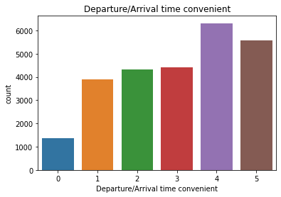

```python
#Distribution of satisfaction level in Departure/Arrival time convenient
sns.countplot(x ='Departure/Arrival time convenient', data = df_1)
plt.title("Departure/Arrival time convenient")
plt.show()
```

```python
print(round((df_1['Departure/Arrival time convenient'].value_counts()/len(df_1['Departure/Arrival time convenient']))*100),2)
```

```
4    24.0
5    22.0
3    17.0
2    17.0
1    15.0
0     5.0
Name: Departure/Arrival time convenient, dtype: float64 2
```

```python
def compare_2_vars(var1, var2):
    fig, ax = plt.subplots(figsize = (9, 6))
    plt.subplot(111)
    sns.countplot(data = df_1, x = var1, hue = var2, order = ["neutral or dissatisfied", "satisfied"])
    plt.tight_layout()
    plt.show()
```

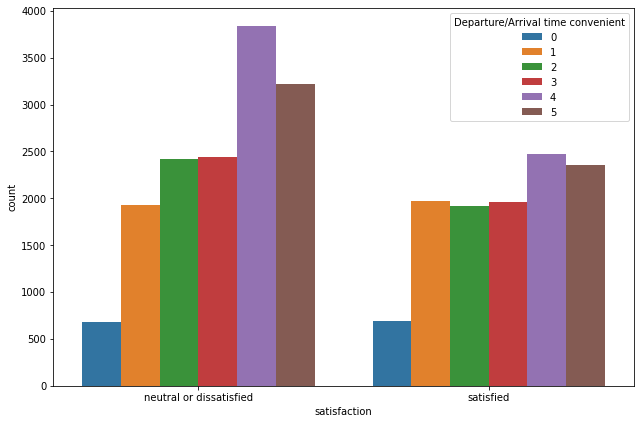

```python
compare_2_vars('satisfaction', 'Departure/Arrival time convenient')
```

Predictive suggestion – The airline can further analyze the cohort of the dissatisfied passengers despite rating the convenience of arrival and departure time based on other factors such as age, gender, class of travel and type of travel.

Prescriptive suggestion – The airline can contact such passengers (dissatisfied passengers who have given a rating 3 and below) via mailers about various options of day and time combinations on which the routes are operational. A similar exercise can also be done with satisfied passengers with a rating of 3 and below.

#### 3. Does the age, gender and type of travel affect the choice of class?

```python
def gender(var1, var2):
    fig, ax = plt.subplots(figsize = (9, 6))
    plt.subplot(111)
    sns.countplot(data = df_1, x = var1, hue = var2, order = ["Male", "Female"])
    plt.tight_layout()
    plt.show()
```

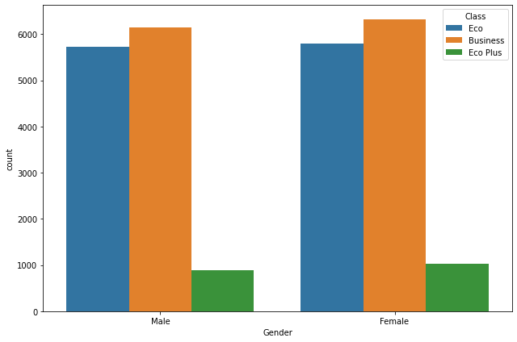

```python
gender('Gender', 'Class')
```

```python
def travel_type(var1, var2):
    fig, ax = plt.subplots(figsize = (9, 6))
    plt.subplot(111)
    sns.countplot(data = df_1, x = var1, hue = var2, order = ["Business travel", "Personal Travel"])
    plt.tight_layout()
    plt.show()
```

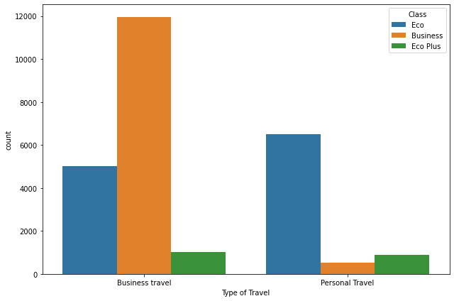

```python
travel_type("Type of Travel", "Class")
```

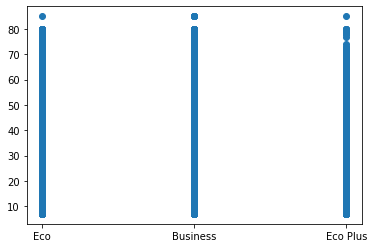

```python
plt.scatter(df_1['Class'],df_1['Age'])
```

The distribution of choice of class in context to gender is almost identical.

We see that extremely high number of passengers traveling for business purpose prefer to travel via business class. There is a possibility that such a scenario has risen as business travel is mostly paid by the company and not the individual.

Predictive suggestion – The airline can use data such as name of the company, different companies among same sector and time of travel during the calendar year to get information about corporate passengers using ‘Eco’ and ‘Eco Plus’ class.

Prescriptive suggestion – The airline can contact such companies and offer them deals so that the economy class passengers choose business class for business purpose travel. They can even tie up with local cab operators and hotels at the frequent destinations as an added service for business class passengers. This way the revenue can be increased as business class tickets would be sold at a higher rate and also, the local cab operators and hotels can be roped in on a revenue sharing model.

#### 4. Does the gate location affect the level of satisfaction?

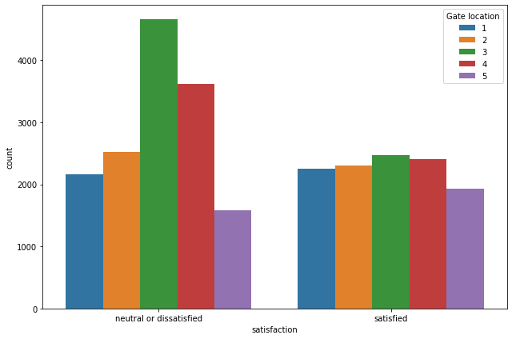

```python
compare_2_vars('satisfaction', 'Gate location')
```

```python
print(round((df_1['Gate location'].value_counts()/len(df_1['Gate location']))*100),2)
```

```
3    28.0
4    23.0
2    19.0
1    17.0
5    14.0
Name: Gate location, dtype: float64 2
```

We can see that a high number of passengers in both cohorts, satisfied as well as dissatisfied have rated the gate location 3 or below. Hence, we can conclude that the gate location plays an important role on the level of satisfaction.

Predictive suggestion – The airline can predict the most convenient arrival and departure time using historic data where they have the maximum passenger traffic and accordingly try to allot a convenient gate location.

Prescriptive suggestion – If a convenient gate location cannot be allotted, the airline can provide a buggy service to transfer the passengers from the security check-in to the allotted gate.

#### 5. What is the trend of ratings for in-flight wifi service and in-flight entertainment in context to the flight distance?

```python
long_distance_flight = df_1[(df_1['Flight Distance'] > 1000)]
long_distance_flight.head()
```

|  | Unnamed: 0 | id | Gender | Customer Type | Age | Type of Travel | Class | Flight Distance | Inflight wifi service | Departure/Arrival time convenient | ... | Inflight entertainment | On-board service | Leg room service | Baggage handling | Checkin service | Inflight service | Cleanliness | Departure Delay in Minutes | Arrival Delay in Minutes | satisfaction |
| --- | --- | --- | --- | --- | --- | --- | --- | --- | --- | --- | --- | --- | --- | --- | --- | --- | --- | --- | --- | --- | --- |
| 1 | 1 | 90035 | Female | Loyal Customer | 36 | Business travel | Business | 2863 | 1 | 1 | ... | 4 | 4 | 4 | 4 | 3 | 4 | 5 | 0 | 0.0 | satisfied |
| 3 | 3 | 77959 | Male | Loyal Customer | 44 | Business travel | Business | 3377 | 0 | 0 | ... | 1 | 1 | 1 | 1 | 3 | 1 | 4 | 0 | 6.0 | satisfied |
| 4 | 4 | 36875 | Female | Loyal Customer | 49 | Business travel | Eco | 1182 | 2 | 3 | ... | 2 | 2 | 2 | 2 | 4 | 2 | 4 | 0 | 20.0 | satisfied |
| 6 | 6 | 79433 | Female | Loyal Customer | 77 | Business travel | Business | 3987 | 5 | 5 | ... | 5 | 5 | 5 | 5 | 4 | 5 | 3 | 0 | 0.0 | satisfied |
| 7 | 7 | 97286 | Female | Loyal Customer | 43 | Business travel | Business | 2556 | 2 | 2 | ... | 4 | 4 | 4 | 4 | 5 | 4 | 3 | 77 | 65.0 | satisfied |

5 rows × 25 columns

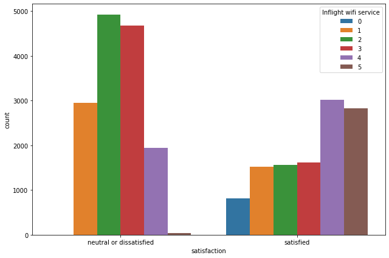

```python
compare_2_vars('satisfaction', 'Inflight wifi service')
```

```python
df_flight_distance=df_1.groupby(['Flight Distance']).mean()
df_flight_distance.head()
```

| Flight Distance | Unnamed: 0 | id | Age | Inflight wifi service | Departure/Arrival time convenient | Ease of Online booking | Gate location | Food and drink | Online boarding | Seat comfort | Inflight entertainment | On-board service | Leg room service | Baggage handling | Checkin service | Inflight service | Cleanliness | Departure Delay in Minutes | Arrival Delay in Minutes |
| --- | --- | --- | --- | --- | --- | --- | --- | --- | --- | --- | --- | --- | --- | --- | --- | --- | --- | --- | --- |
| 31 | 4922.333333 | 30053.666667 | 45.000000 | 3.000000 | 4.000000 | 1.666667 | 3.666667 | 4.000000 | 2.333333 | 3.000000 | 4.000000 | 4.000000 | 4.666667 | 4.000000 | 3.666667 | 3.666667 | 4.000000 | 2.666667 | 5.000000 |
| 56 | 15089.666667 | 49790.000000 | 26.000000 | 1.666667 | 3.000000 | 2.000000 | 3.000000 | 4.000000 | 2.333333 | 3.666667 | 3.666667 | 3.000000 | 4.000000 | 3.000000 | 3.666667 | 3.666667 | 3.666667 | 24.333333 | 30.666667 |
| 67 | 14114.750000 | 38517.562500 | 39.250000 | 2.718750 | 3.312500 | 2.437500 | 2.718750 | 2.687500 | 2.968750 | 3.093750 | 2.875000 | 3.562500 | 3.250000 | 3.343750 | 3.343750 | 3.625000 | 2.656250 | 30.812500 | 35.437500 |
| 73 | 13607.555556 | 41493.277778 | 41.166667 | 2.888889 | 2.111111 | 2.500000 | 2.722222 | 2.888889 | 2.666667 | 2.611111 | 2.777778 | 2.444444 | 3.222222 | 2.888889 | 2.277778 | 3.166667 | 2.944444 | 38.666667 | 39.722222 |
| 74 | 10577.000000 | 16284.916667 | 38.083333 | 2.416667 | 3.000000 | 2.750000 | 2.666667 | 3.083333 | 3.500000 | 3.500000 | 3.250000 | 3.166667 | 3.166667 | 3.666667 | 3.416667 | 3.333333 | 3.250000 | 5.666667 | 7.416667 |

We have considered a long duration flight as the one which travels more than 1,000 miles. One limitation is that no data is available if there is a stop-over in such flights. From the analysis above, in-flight wifi service is an important factor to determine the level of satisfaction. Majority of the dissatisfied passengers have rated the in-flight wifi service 3 or below. On the contrary, majority of the satisfied passengers have rated the in-flight wifi 4 or above.

Predictive suggestion – The longer the flight distance, the more difficult it is to keep the passengers satisfied.

Prescriptive suggestion – For long duration flights, better in-flight entertainment such as playing cards or small board games can be provided. Also, free wifi service can be made available for certain slots depending on the time-zone so that the passengers are able to communicate with their family and friends. It would also be helpful to appease the business purpose passengers as they would have access to e-mails.

#### 6. Do the age criteria have any effect on ratings for ease of online booking and online boarding?

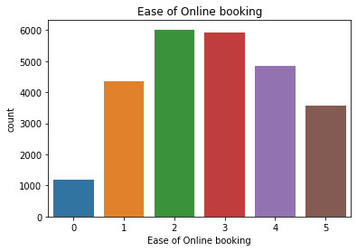

```python
sns.countplot(x ='Ease of Online booking', data = df_1)
plt.title("Ease of Online booking")
plt.show()
```

```python
df_age=df_1.groupby(['Age']).mean()
df_age.head()
```

| Age | Unnamed: 0 | id | Flight Distance | Inflight wifi service | Departure/Arrival time convenient | Ease of Online booking | Gate location | Food and drink | Online boarding | Seat comfort | Inflight entertainment | On-board service | Leg room service | Baggage handling | Checkin service | Inflight service | Cleanliness | Departure Delay in Minutes | Arrival Delay in Minutes |
| --- | --- | --- | --- | --- | --- | --- | --- | --- | --- | --- | --- | --- | --- | --- | --- | --- | --- | --- | --- |
| 7 | 12231.688525 | 70043.147541 | 908.663934 | 2.614754 | 3.786885 | 2.639344 | 2.770492 | 2.885246 | 2.614754 | 2.852459 | 2.893443 | 3.286885 | 3.163934 | 3.745902 | 3.278689 | 3.729508 | 2.909836 | 14.131148 | 14.459016 |
| 8 | 12647.987179 | 60108.070513 | 862.500000 | 2.378205 | 3.474359 | 2.423077 | 2.801282 | 2.942308 | 2.467949 | 2.923077 | 2.948718 | 3.269231 | 3.224359 | 3.852564 | 3.371795 | 3.897436 | 2.942308 | 19.923077 | 21.423077 |
| 9 | 13416.400000 | 64834.909091 | 847.472727 | 2.606061 | 3.309091 | 2.612121 | 2.951515 | 2.775758 | 2.654545 | 2.830303 | 2.769697 | 3.151515 | 3.236364 | 3.678788 | 3.260606 | 3.672727 | 2.787879 | 10.006061 | 11.460606 |
| 10 | 13287.611511 | 73537.050360 | 876.949640 | 2.410072 | 3.244604 | 2.309353 | 3.021583 | 3.093525 | 2.359712 | 3.079137 | 3.129496 | 3.223022 | 2.971223 | 3.748201 | 3.323741 | 3.805755 | 3.179856 | 20.812950 | 21.769784 |
| 11 | 13355.685535 | 64889.805031 | 897.761006 | 2.490566 | 3.383648 | 2.603774 | 2.880503 | 3.050314 | 2.584906 | 2.968553 | 3.062893 | 3.238994 | 3.320755 | 3.792453 | 3.358491 | 3.754717 | 3.062893 | 14.138365 | 14.125786 |

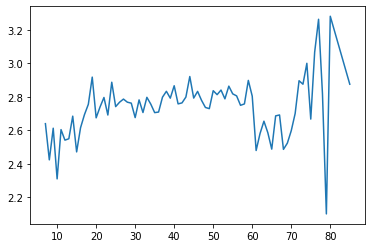

```python
plt.plot(df_age['Ease of Online booking'])
plt.show()
```

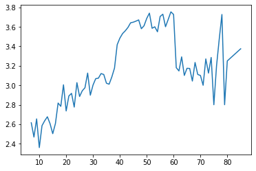

```python
plt.plot(df_age['Online boarding'])
plt.show()
```

Similarly, when analyzing with type of travel, the business class passengers seem to have given a better rating as the histogram can be seen skewed to the right.

Predictive suggestion – The airline can predict the category of passengers and classify them in smaller groups based on age and travel. This would help them predict the range of ratings when a similar group would travel.

Prescriptive suggestion – Whenever a similar group travels where there is lower rating for seat comfort and leg space, the airline can offer a class upgrade (based on availability) or give priority for such customers to book seats near fire exits for additional leg room.

#### 7. Do age and type of travel have any effect on the ratings for seat comfort and leg room service?

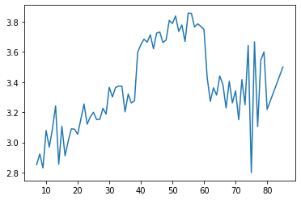

```python
plt.plot(df_age['Seat comfort'])
plt.show()
```

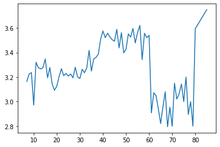

```python
plt.plot(df_age['Leg room service'])
plt.show()
```

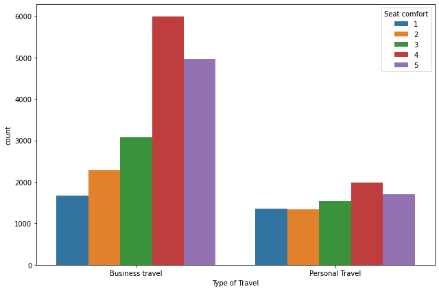

```python
travel_type("Type of Travel", "Seat comfort")
```

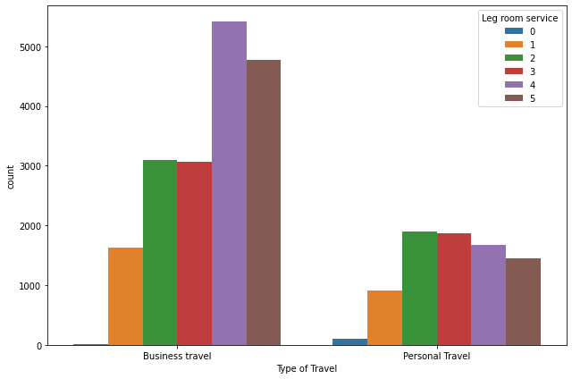

```python
travel_type("Type of Travel", "Leg room service")
```

For the first 3 quartiles, i.e. for the age group from 7 to 51, we see that the rating is between 2.3 and 2.9. Here, we are referring to the age group that we can say to be conversant with technology. So we can infer that the airline has to work more on smoothening the online booking process.

Predictive suggestion – Using historic data the airline can predict the age group that prefers to travel during a particular time of the year.

Prescriptive suggestion – Depending on the age group of passengers analyzed using predictive suggestion, the airline can concentrate if online booking and online boarding can be worked upon. For example, if for a particular flight, the passenger cohort is young, the airline can suggest the passengers to do online boarding and keep a very few counters open for physical check-in.

#### 8. What is the trend of ratings for food and drink in context of the gender of the passenger?

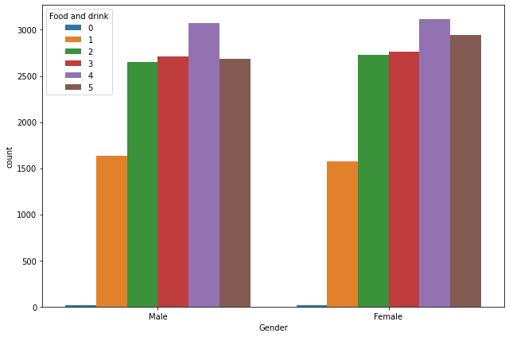

```python
gender('Gender', 'Food and drink')
```

Analyzing both the histograms, we can see that the ratings for food and drink irrespective of gender are almost equally distributed in terms of count. It is because of such a distribution, it is difficult to prescribe a suggestion to the airline for areas of improvement.

Predictive suggestion – Since there are only two variables, the airline can predict the range of ratings for food and drink given the gender.

Prescriptive suggestion – If the trip consists of one gender majorly, the menu can be tweaked according to the preferences.

#### 9. What is the correlation between the type of customer and the level of satisfaction? Is it logical to assume that a loyal customer would be satisfied irrespective of the ratings?

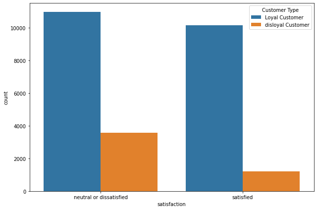

```python
compare_2_vars('satisfaction', 'Customer Type')
```

Predictive suggestion – The airline can predict if the type of customer is related to the level of satisfaction.

Prescriptive suggestion – The airline may have to deep dive in the criteria which tags a passenger as loyal or disloyal.

```python
def satisfaction_scale(df_1):
    if df_1['satisfaction'] == 'satisfied':
        return 1
    else:
        return 0
df_1['satisfaction_scale'] = df_1.apply(satisfaction_scale, axis=1)
df_1.head()
```

[output not shown]

5 rows × 28 columns

```python
def customer_type_scale(df_1):
    if df_1['Customer Type'] == "Loyal Customer":
        return 1
    else:
        return 0
df_1['customer_type_scale'] = df_1.apply(customer_type_scale, axis=1)
df_1.head()
```

[output not shown]

5 rows × 29 columns

```python
correlation = df_1['satisfaction_scale'].corr(df_1['customer_type_scale'])
correlation
```

```
0.1794822606093637
```

We can see that the correlation between the satisfaction and type of customer though positive, is not strong. We cannot say that a customer though classified as loyal, cannot be said to be satisfied with the overall flight experience. The criteria using which the airline decides the loyalty of a passenger needs to be re-evaluated.

#### 10. Given the type of travel and the delay in arrival and departure being a non-null value, does it affect the satisfaction?

We have combined two columns Departure Delay in Minutes and Arrival Delay in Minutes and treated the same as one single variable for addressing this question.

```python
df_1['Departure/Arrival Delay in Minutes'] = df_1['Departure Delay in Minutes'] + df_1['Arrival Delay in Minutes']
```

```python
df_1['Departure/Arrival Delay in Minutes'].head()
```

```
0    94.0
1     0.0
2     0.0
3     6.0
4    20.0
Name: Departure/Arrival Delay in Minutes, dtype: float64
```

```python
def change(df_1):
    if df_1['Departure/Arrival Delay in Minutes'] == 0.0:
        return 0
    else:
        return 1
df_1['New Departure/Arrival Delay in Minutes'] = df_1.apply(change, axis = 1)
df_1.head()
```

|  | Unnamed: 0 | id | Gender | Customer Type | Age | Type of Travel | Class | Flight Distance | Inflight wifi service | Departure/Arrival time convenient | ... | Leg room service | Baggage handling | Checkin service | Inflight service | Cleanliness | Departure Delay in Minutes | Arrival Delay in Minutes | satisfaction | Departure/Arrival Delay in Minutes | New Departure/Arrival Delay in Minutes |
| --- | --- | --- | --- | --- | --- | --- | --- | --- | --- | --- | --- | --- | --- | --- | --- | --- | --- | --- | --- | --- | --- |
| 0 | 0 | 19556 | Female | Loyal Customer | 52 | Business travel | Eco | 160 | 5 | 4 | ... | 5 | 5 | 2 | 5 | 5 | 50 | 44.0 | satisfied | 94.0 | 1 |
| 1 | 1 | 90035 | Female | Loyal Customer | 36 | Business travel | Business | 2863 | 1 | 1 | ... | 4 | 4 | 3 | 4 | 5 | 0 | 0.0 | satisfied | 0.0 | 0 |
| 2 | 2 | 12360 | Male | disloyal Customer | 20 | Business travel | Eco | 192 | 2 | 0 | ... | 1 | 3 | 2 | 2 | 2 | 0 | 0.0 | neutral or dissatisfied | 0.0 | 0 |
| 3 | 3 | 77959 | Male | Loyal Customer | 44 | Business travel | Business | 3377 | 0 | 0 | ... | 1 | 1 | 3 | 1 | 4 | 0 | 6.0 | satisfied | 6.0 | 1 |
| 4 | 4 | 36875 | Female | Loyal Customer | 49 | Business travel | Eco | 1182 | 2 | 3 | ... | 2 | 2 | 4 | 2 | 4 | 0 | 20.0 | satisfied | 20.0 | 1 |

5 rows × 27 columns

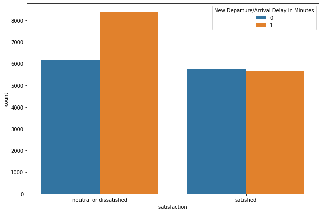

```python
compare_2_vars('satisfaction', 'New Departure/Arrival Delay in Minutes')
```

For this question, we have combined the arrival delay and departure delay columns. Then if both the columns have '0' i.e. no delay in either arrival or departure, the column is tagged as 0, else 1.

The analysis for dissatisfied/neutral passengers is logical as more number of passengers are dissatisfied. However, for the satisfied passengers cohort, we can see that almost equal number of flights were delayed or not.

The airline can analyse these flights for the trend of other ratings to derive insights for the passengers being satisfied inspite of the flight being delayed. Those insights can be useful to improve the overall flight experience.

## Hypothesis

#### Hypothesis 1

H0: A female passenger travelling business class is satisfied with the flight experience.  
HA: A female passenger travelling business class is dissatisfied with the flight experience.

```python
female_number = df_1[(df_1['Gender'] == 'Female')]
female_number.head()
```

|  | Unnamed: 0 | id | Gender | Customer Type | Age | Type of Travel | Class | Flight Distance | Inflight wifi service | Departure/Arrival time convenient | ... | Checkin service | Inflight service | Cleanliness | Departure Delay in Minutes | Arrival Delay in Minutes | satisfaction | Departure/Arrival Delay in Minutes | New Departure/Arrival Delay in Minutes | satisfaction_scale | customer_type_scale |
| --- | --- | --- | --- | --- | --- | --- | --- | --- | --- | --- | --- | --- | --- | --- | --- | --- | --- | --- | --- | --- | --- |
| 0 | 0 | 19556 | Female | Loyal Customer | 52 | Business travel | Eco | 160 | 5 | 4 | ... | 2 | 5 | 5 | 50 | 44.0 | satisfied | 94.0 | 1 | 1 | 1 |
| 1 | 1 | 90035 | Female | Loyal Customer | 36 | Business travel | Business | 2863 | 1 | 1 | ... | 3 | 4 | 5 | 0 | 0.0 | satisfied | 0.0 | 0 | 1 | 1 |
| 4 | 4 | 36875 | Female | Loyal Customer | 49 | Business travel | Eco | 1182 | 2 | 3 | ... | 4 | 2 | 4 | 0 | 20.0 | satisfied | 20.0 | 1 | 1 | 1 |
| 6 | 6 | 79433 | Female | Loyal Customer | 77 | Business travel | Business | 3987 | 5 | 5 | ... | 4 | 5 | 3 | 0 | 0.0 | satisfied | 0.0 | 0 | 1 | 1 |
| 7 | 7 | 97286 | Female | Loyal Customer | 43 | Business travel | Business | 2556 | 2 | 2 | ... | 5 | 4 | 3 | 77 | 65.0 | satisfied | 142.0 | 1 | 1 | 1 |

5 rows × 29 columns

```python
female_business_class = female_number[(female_number.Class == 'Business')]
female_business_class.head()
```

|  | Unnamed: 0 | id | Gender | Customer Type | Age | Type of Travel | Class | Flight Distance | Inflight wifi service | Departure/Arrival time convenient | ... | Checkin service | Inflight service | Cleanliness | Departure Delay in Minutes | Arrival Delay in Minutes | satisfaction | Departure/Arrival Delay in Minutes | New Departure/Arrival Delay in Minutes | satisfaction_scale | customer_type_scale |
| --- | --- | --- | --- | --- | --- | --- | --- | --- | --- | --- | --- | --- | --- | --- | --- | --- | --- | --- | --- | --- | --- |
| 1 | 1 | 90035 | Female | Loyal Customer | 36 | Business travel | Business | 2863 | 1 | 1 | ... | 3 | 4 | 5 | 0 | 0.0 | satisfied | 0.0 | 0 | 1 | 1 |
| 6 | 6 | 79433 | Female | Loyal Customer | 77 | Business travel | Business | 3987 | 5 | 5 | ... | 4 | 5 | 3 | 0 | 0.0 | satisfied | 0.0 | 0 | 1 | 1 |
| 7 | 7 | 97286 | Female | Loyal Customer | 43 | Business travel | Business | 2556 | 2 | 2 | ... | 5 | 4 | 3 | 77 | 65.0 | satisfied | 142.0 | 1 | 1 | 1 |
| 9 | 9 | 62482 | Female | Loyal Customer | 46 | Business travel | Business | 1744 | 2 | 2 | ... | 5 | 4 | 4 | 28 | 14.0 | satisfied | 42.0 | 1 | 1 | 1 |
| 11 | 11 | 115550 | Female | Loyal Customer | 33 | Business travel | Business | 325 | 2 | 5 | ... | 3 | 2 | 4 | 18 | 7.0 | neutral or dissatisfied | 25.0 | 1 | 0 | 1 |

5 rows × 29 columns

```python
female_business_class['satisfaction'].value_counts(normalize=True)
```

```
satisfied                  0.691808
neutral or dissatisfied    0.308192
Name: satisfaction, dtype: float64
```

```python
def female_business_class(df_1):
    if df_1['Gender'] == 'Female' and df_1['Class'] == 'Business':
        return 1
    else:
        return 0
df_1['Female_Business_Class'] = df_1.apply(female_business_class, axis = 1)
```

```python
model=smf.ols(formula='satisfaction_scale~Female_Business_Class',data=df_1)
results=model.fit()
print(results.summary())
```

```
                            OLS Regression Results
==============================================================================
Dep. Variable:     satisfaction_scale   R-squared:                       0.084
Model:                            OLS   Adj. R-squared:                  0.084
Method:                 Least Squares   F-statistic:                     2365.
Date:                Mon, 29 Nov 2021   Prob (F-statistic):               0.00
Time:                        04:19:26   Log-Likelihood:                -17467.
No. Observations:               25893   AIC:                         3.494e+04
Df Residuals:                   25891   BIC:                         3.495e+04
Df Model:                           1
Covariance Type:            nonrobust
=========================================================================================
                            coef    std err          t      P>|t|      [0.025      0.975]
-----------------------------------------------------------------------------------------
Intercept                 0.3574      0.003    105.285      0.000       0.351       0.364
Female_Business_Class     0.3344      0.007     48.629      0.000       0.321       0.348
==============================================================================
Omnibus:                   134057.103   Durbin-Watson:                   2.013
Prob(Omnibus):                  0.000   Jarque-Bera (JB):             2993.248
Skew:                           0.276   Prob(JB):                         0.00
Kurtosis:                       1.429   Cond. No.                         2.50
==============================================================================

Notes:
[1] Standard Errors assume that the covariance matrix of the errors is correctly specified.
```

Here, from summary table we can see that t-statistic for satisfaction intercept is 105.285 and that for a female passenger traveling business class is 48.629. We can see that the p-value is 0 which in fact is not exactly 0 but very close to 0 as we have very large t-statistics.

R-squared value explains us about how much percentage change can in 'x' (female passenger traveling business class in our case) can be explained by 'y' (level of satisfaction in our case). In our case this variable is low at 8.40%. It means the regression is very skewed in our case.

#### Hypothesis 2

H0: A male passenger travelling business class is satisfied with the flight experience.  
HA: A male passenger travelling business class is dissatisfied with the flight experience.

```python
male_number = df_1[(df_1['Gender'] == 'Male')]
male_number.head()
```

|  | Unnamed: 0 | id | Gender | Customer Type | Age | Type of Travel | Class | Flight Distance | Inflight wifi service | Departure/Arrival time convenient | ... | Inflight service | Cleanliness | Departure Delay in Minutes | Arrival Delay in Minutes | satisfaction | Departure/Arrival Delay in Minutes | New Departure/Arrival Delay in Minutes | satisfaction_scale | customer_type_scale | Female_Business_Class |
| --- | --- | --- | --- | --- | --- | --- | --- | --- | --- | --- | --- | --- | --- | --- | --- | --- | --- | --- | --- | --- | --- |
| 2 | 2 | 12360 | Male | disloyal Customer | 20 | Business travel | Eco | 192 | 2 | 0 | ... | 2 | 2 | 0 | 0.0 | neutral or dissatisfied | 0.0 | 0 | 0 | 0 | 0 |
| 3 | 3 | 77959 | Male | Loyal Customer | 44 | Business travel | Business | 3377 | 0 | 0 | ... | 1 | 4 | 0 | 6.0 | satisfied | 6.0 | 1 | 1 | 1 | 0 |
| 5 | 5 | 39177 | Male | Loyal Customer | 16 | Business travel | Eco | 311 | 3 | 3 | ... | 2 | 5 | 0 | 0.0 | satisfied | 0.0 | 0 | 1 | 1 | 0 |
| 8 | 8 | 27508 | Male | Loyal Customer | 47 | Business travel | Eco | 556 | 5 | 2 | ... | 3 | 5 | 1 | 0.0 | satisfied | 1.0 | 1 | 1 | 1 | 0 |
| 15 | 15 | 22470 | Male | Loyal Customer | 50 | Personal Travel | Eco | 83 | 3 | 4 | ... | 5 | 2 | 5 | 2.0 | neutral or dissatisfied | 7.0 | 1 | 0 | 1 | 0 |

5 rows × 30 columns

```python
male_business_class = male_number[(male_number.Class == 'Business')]
male_business_class.head()
```

|  | Unnamed: 0 | id | Gender | Customer Type | Age | Type of Travel | Class | Flight Distance | Inflight wifi service | Departure/Arrival time convenient | ... | Inflight service | Cleanliness | Departure Delay in Minutes | Arrival Delay in Minutes | satisfaction | Departure/Arrival Delay in Minutes | New Departure/Arrival Delay in Minutes | satisfaction_scale | customer_type_scale | Female_Business_Class |
| --- | --- | --- | --- | --- | --- | --- | --- | --- | --- | --- | --- | --- | --- | --- | --- | --- | --- | --- | --- | --- | --- |
| 3 | 3 | 77959 | Male | Loyal Customer | 44 | Business travel | Business | 3377 | 0 | 0 | ... | 1 | 4 | 0 | 6.0 | satisfied | 6.0 | 1 | 1 | 1 | 0 |
| 20 | 20 | 63995 | Male | Loyal Customer | 60 | Business travel | Business | 612 | 4 | 4 | ... | 5 | 5 | 21 | 49.0 | satisfied | 70.0 | 1 | 1 | 1 | 0 |
| 23 | 23 | 44304 | Male | Loyal Customer | 25 | Business travel | Business | 1428 | 4 | 4 | ... | 5 | 4 | 0 | 0.0 | satisfied | 0.0 | 0 | 1 | 1 | 0 |
| 26 | 26 | 127781 | Male | Loyal Customer | 24 | Business travel | Business | 3680 | 4 | 1 | ... | 4 | 2 | 0 | 0.0 | satisfied | 0.0 | 0 | 1 | 1 | 0 |
| 28 | 28 | 121658 | Male | Loyal Customer | 44 | Business travel | Business | 1543 | 3 | 5 | ... | 5 | 5 | 0 | 0.0 | satisfied | 0.0 | 0 | 1 | 1 | 0 |

5 rows × 30 columns

```python
male_business_class['satisfaction'].value_counts(normalize=True)
```

```
satisfied                  0.698666
neutral or dissatisfied    0.301334
Name: satisfaction, dtype: float64
```

```python
def male_business_class(df_1):
    if df_1['Gender'] == 'Male' and df_1['Class'] == 'Business':
        return 1
    else:
        return 0
df_1['Male_Business_Class'] = df_1.apply(male_business_class, axis = 1)
```

```python
model=smf.ols(formula='satisfaction_scale~Male_Business_Class',data=df_1)
results=model.fit()
print(results.summary())
```

```
                            OLS Regression Results
==============================================================================
Dep. Variable:     satisfaction_scale   R-squared:                       0.085
Model:                            OLS   Adj. R-squared:                  0.085
Method:                 Least Squares   F-statistic:                     2413.
Date:                Mon, 29 Nov 2021   Prob (F-statistic):               0.00
Time:                        04:20:07   Log-Likelihood:                -17444.
No. Observations:               25893   AIC:                         3.489e+04
Df Residuals:                   25891   BIC:                         3.491e+04
Df Model:                           1
Covariance Type:            nonrobust
=======================================================================================
                          coef    std err          t      P>|t|      [0.025      0.975]
---------------------------------------------------------------------------------------
Intercept               0.3581      0.003    106.013      0.000       0.351       0.365
Male_Business_Class     0.3406      0.007     49.126      0.000       0.327       0.354
==============================================================================
Omnibus:                   135683.150   Durbin-Watson:                   2.003
Prob(Omnibus):                  0.000   Jarque-Bera (JB):             2979.602
Skew:                           0.280   Prob(JB):                         0.00
Kurtosis:                       1.435   Cond. No.                         2.51
==============================================================================

Notes:
[1] Standard Errors assume that the covariance matrix of the errors is correctly specified.
```

Here, from summary table we can see that t-statistic for satisfaction intercept is 106.013 and that for a male passenger traveling business class is 49.126. We can see that the p-value is 0 which in fact is not exactly 0 but very close to 0 as we have very large t-statistics.

R-squared value explains us about how much percentage change can in 'x' (male passenger traveling business class in our case) can be explained by 'y' (level of satisfaction in our case). In our case this variable is low at 8.50%. It means the regression is very skewed in our case.

#### Hypothesis 3

H0: A female passenger travelling economy class is satisfied with the flight experience.  
HA: A female passenger travelling economy class is dissatisfied with the flight experience.

```python
female_eco_class = female_number[(female_number.Class == 'Eco')]
female_eco_class.head()
```

|  | Unnamed: 0 | id | Gender | Customer Type | Age | Type of Travel | Class | Flight Distance | Inflight wifi service | Departure/Arrival time convenient | ... | Checkin service | Inflight service | Cleanliness | Departure Delay in Minutes | Arrival Delay in Minutes | satisfaction | Departure/Arrival Delay in Minutes | New Departure/Arrival Delay in Minutes | satisfaction_scale | customer_type_scale |
| --- | --- | --- | --- | --- | --- | --- | --- | --- | --- | --- | --- | --- | --- | --- | --- | --- | --- | --- | --- | --- | --- |
| 0 | 0 | 19556 | Female | Loyal Customer | 52 | Business travel | Eco | 160 | 5 | 4 | ... | 2 | 5 | 5 | 50 | 44.0 | satisfied | 94.0 | 1 | 1 | 1 |
| 4 | 4 | 36875 | Female | Loyal Customer | 49 | Business travel | Eco | 1182 | 2 | 3 | ... | 4 | 2 | 4 | 0 | 20.0 | satisfied | 20.0 | 1 | 1 | 1 |
| 10 | 10 | 47583 | Female | Loyal Customer | 47 | Business travel | Eco | 1235 | 4 | 1 | ... | 1 | 3 | 4 | 29 | 19.0 | satisfied | 48.0 | 1 | 1 | 1 |
| 16 | 16 | 124915 | Female | Loyal Customer | 31 | Business travel | Eco | 728 | 2 | 5 | ... | 4 | 3 | 2 | 2 | 0.0 | neutral or dissatisfied | 2.0 | 1 | 0 | 1 |
| 18 | 18 | 76872 | Female | Loyal Customer | 43 | Personal Travel | Eco | 1927 | 3 | 4 | ... | 4 | 5 | 3 | 0 | 0.0 | neutral or dissatisfied | 0.0 | 0 | 0 | 1 |

5 rows × 29 columns

```python
female_eco_class['satisfaction'].value_counts(normalize=True)
```

```
neutral or dissatisfied    0.809318
satisfied                  0.190682
Name: satisfaction, dtype: float64
```

```python
def female_eco_class(df_1):
    if df_1['Gender'] == 'Female' and df_1['Class'] == 'Eco':
        return 1
    else:
        return 0
df_1['Female_Eco_Class'] = df_1.apply(female_business_class, axis = 1)
```

```python
model=smf.ols(formula='satisfaction_scale~Female_Eco_Class',data=df_1)
results=model.fit()
print(results.summary())
```

```
                            OLS Regression Results
==============================================================================
Dep. Variable:     satisfaction_scale   R-squared:                       0.084
Model:                            OLS   Adj. R-squared:                  0.084
Method:                 Least Squares   F-statistic:                     2365.
Date:                Mon, 29 Nov 2021   Prob (F-statistic):               0.00
Time:                        04:28:00   Log-Likelihood:                -17467.
No. Observations:               25893   AIC:                         3.494e+04
Df Residuals:                   25891   BIC:                         3.495e+04
Df Model:                           1
Covariance Type:            nonrobust
====================================================================================
                       coef    std err          t      P>|t|      [0.025      0.975]
------------------------------------------------------------------------------------
Intercept            0.3574      0.003    105.285      0.000       0.351       0.364
Female_Eco_Class     0.3344      0.007     48.629      0.000       0.321       0.348
==============================================================================
Omnibus:                   134057.103   Durbin-Watson:                   2.013
Prob(Omnibus):                  0.000   Jarque-Bera (JB):             2993.248
Skew:                           0.276   Prob(JB):                         0.00
Kurtosis:                       1.429   Cond. No.                         2.50
==============================================================================

Notes:
[1] Standard Errors assume that the covariance matrix of the errors is correctly specified.
```

#### Hypothesis 4

H0: A male passenger travelling economy class is dissatisfied with the flight experience.  
HA: A male passenger travelling economy class is satisfied with the flight experience.

```python
male_eco_class = male_number[(male_number.Class == 'Eco')]
male_eco_class.head()
```

|  | Unnamed: 0 | id | Gender | Customer Type | Age | Type of Travel | Class | Flight Distance | Inflight wifi service | Departure/Arrival time convenient | ... | Inflight service | Cleanliness | Departure Delay in Minutes | Arrival Delay in Minutes | satisfaction | Departure/Arrival Delay in Minutes | New Departure/Arrival Delay in Minutes | satisfaction_scale | customer_type_scale | Female_Business_Class |
| --- | --- | --- | --- | --- | --- | --- | --- | --- | --- | --- | --- | --- | --- | --- | --- | --- | --- | --- | --- | --- | --- |
| 2 | 2 | 12360 | Male | disloyal Customer | 20 | Business travel | Eco | 192 | 2 | 0 | ... | 2 | 2 | 0 | 0.0 | neutral or dissatisfied | 0.0 | 0 | 0 | 0 | 0 |
| 5 | 5 | 39177 | Male | Loyal Customer | 16 | Business travel | Eco | 311 | 3 | 3 | ... | 2 | 5 | 0 | 0.0 | satisfied | 0.0 | 0 | 1 | 1 | 0 |
| 8 | 8 | 27508 | Male | Loyal Customer | 47 | Business travel | Eco | 556 | 5 | 2 | ... | 3 | 5 | 1 | 0.0 | satisfied | 1.0 | 1 | 1 | 1 | 0 |
| 15 | 15 | 22470 | Male | Loyal Customer | 50 | Personal Travel | Eco | 83 | 3 | 4 | ... | 5 | 2 | 5 | 2.0 | neutral or dissatisfied | 7.0 | 1 | 0 | 1 | 0 |
| 21 | 21 | 75855 | Male | Loyal Customer | 43 | Personal Travel | Eco | 1437 | 3 | 4 | ... | 5 | 2 | 0 | 0.0 | neutral or dissatisfied | 0.0 | 0 | 0 | 1 | 0 |

5 rows × 30 columns

```python
male_eco_class['satisfaction'].value_counts(normalize=True)
```

```
neutral or dissatisfied    0.803456
satisfied                  0.196544
Name: satisfaction, dtype: float64
```

```python
def male_eco_class(df_1):
    if df_1['Gender'] == 'Male' and df_1['Class'] == 'Eco':
        return 1
    else:
        return 0
df_1['Male_Eco_Class'] = df_1.apply(male_business_class, axis = 1)
```

```python
model=smf.ols(formula='satisfaction_scale~Male_Eco_Class',data=df_1)
results=model.fit()
print(results.summary())
```

```
                            OLS Regression Results
==============================================================================
Dep. Variable:     satisfaction_scale   R-squared:                       0.085
Model:                            OLS   Adj. R-squared:                  0.085
Method:                 Least Squares   F-statistic:                     2413.
Date:                Mon, 29 Nov 2021   Prob (F-statistic):               0.00
Time:                        04:33:10   Log-Likelihood:                -17444.
No. Observations:               25893   AIC:                         3.489e+04
Df Residuals:                   25891   BIC:                         3.491e+04
Df Model:                           1
Covariance Type:            nonrobust
==================================================================================
                     coef    std err          t      P>|t|      [0.025      0.975]
----------------------------------------------------------------------------------
Intercept          0.3581      0.003    106.013      0.000       0.351       0.365
Male_Eco_Class     0.3406      0.007     49.126      0.000       0.327       0.354
==============================================================================
Omnibus:                   135683.150   Durbin-Watson:                   2.003
Prob(Omnibus):                  0.000   Jarque-Bera (JB):             2979.602
Skew:                           0.280   Prob(JB):                         0.00
Kurtosis:                       1.435   Cond. No.                         2.51
==============================================================================

Notes:
[1] Standard Errors assume that the covariance matrix of the errors is correctly specified.
```

#### Final Analysis

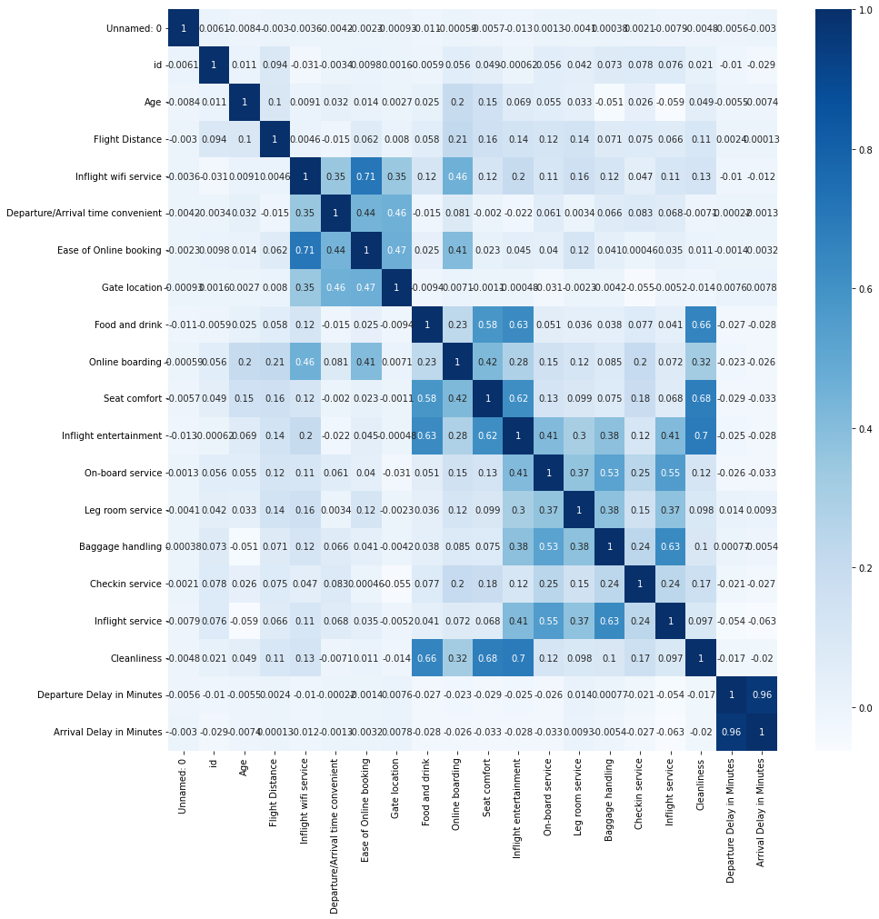

```python
flight_cor=df_1.corr()
flight_cor
fig, ax = plt.subplots(figsize=(15,15))
sns.heatmap(flight_cor, annot=True, cmap='Blues')
plt.show()
```

## 3. Conclusion

#### The summary of findings:

Especially keeping the COVID situation in mind, following all the protocols, the airline needs to work hard on improving the flight experience.

#### Business implications for audience:

The individual business implications have been addressed with the particular business and analysis questions raised. For an overall analysis, we feel that the criteria for classifying a passenger as loyal / disloyal needs to be revisited. Also, the individual suggestions given need to be considered by the airline.

#### Limitations of this project

Some of the variables are left unrated by the passengers. It cannot be established whether this act was arbitrary or if the customers did not have any opinion.

We cannot establish if they type of customer as rated by the airline has an impact on the ratings given by the passenger.

The data set has three types of satisfaction criteria: satisfied, neutral or dissatisfied. However, dissatisfied, and neutral are combined. As per our logic, the possibility of a neutral passenger using the airline again for travel is more than a dissatisfied passenger. The data set should have been made keeping neutral and dissatisfied criteria separate.

Outliers; especially in the ‘Departure Delay in Minutes’ and ‘Arrival Delay in Minutes’ columns are mainly responsible for the skewness for the normal distribution. Also, we believe that since both these columns have a significant impact on the satisfaction rating, we cannot rule out the possibility of an element of biasness in the final satisfaction rating

The location of gate is not always decided by the airline. Other than the long term leased gates (the airline has the autonomy to use these gates), the airline sometimes must use common gates (the airport authority decides the allocation). Hence, we cannot suggest any prescriptive analytics for a lower rating for convenience of ‘Gate location’ as it may not be implementable.(https://www.quora.com/How-do-airports-assign-flights-to-gates)

#### Potential project by adopting advanced analytics techniques such as predictive and prescriptive analytics

The same is suggested along with the individual analysis questions in form of suggestions. The respective managers may work on the individual suggestions based on statistical analysis and try to implement the prescriptive measures suggested.